# Introduction to the bSMED package

Collin Erickson

2017-09-09

This package implements the adaptive sampling algorithm from the paper “Batch Sequential Minimum Energy Design with Design-Region Adaptation” by Heeyoung Kim et al. (2017), published in Journal of Quality Technology Vol. 49, No. 1, January 2017.

I have used the abbreviation `bSMED` to refer to this method. The main function provided by this package is the `bSMED` function, which creates an R6 object that performs the algorithm.

## Demonstration on quad_peaks_slant

To demonstrate how this package works we use the bSMED package to find the maximum of the quad_peaks_slant function in two dimensions. The contour plot below shows that there are four peaks (pink areas) with valleys between them. This is a difficult function to optimize since it is not convex and has multiple local optima.

```r
set.seed(0) # 0 for text in here, 3 to get missed peak
```

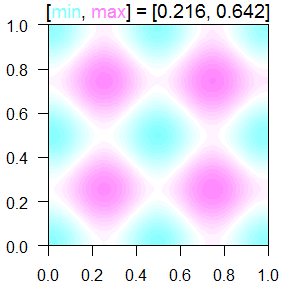

```r
quad_peaks_slant <- TestFunctions::add_linear_terms(function(XX) {.2+.015*TestFunctions::add_zoom(TestFunctions::rastrigin, scale_low = c(.4,.4), scale_high = c(.6,.6))(XX)^.9}, coeffs = c(.02,.01))
ContourFunctions::cf(quad_peaks_slant)
```

We create a bSMED R6 object using bSMED$new and passing in the parameters we want to set.

- D: Number of dimensions the function has
- func: The function we are using
- obj: “func” means that we want to maximize the function value
- b: The batch size
- nb: The number of batches we will take in our experiment
- X0: The initial design
- Xopts: The points that are available to be selected

```r
a <- bSMED::bSMED$new(D=2,func=quad_peaks_slant,
                      obj="func", b=3, nb=5,
                      X0=lhs::maximinLHS(20,2),
                      Xopts=lhs::maximinLHS(500,2),
                      package="GauPro",
                      parallel=FALSE
                      )
```

### First iteration

To run the experiment, we can simply call `a$run()`. Below we run only the first iteration and plot the results. The first iteration simply runs the `X0` points passed in, so there is no decision making. It only evaluates the function at the given points and fits a model to it. The top left plot shows the predicted surface, the top right plot shows the predictive variance of the model. The red circles on the top right plot show the points that are available to be selected but haven’t been selected yet. The bottom left plot shows the actual surface, the bottom right plot shows the squared error.

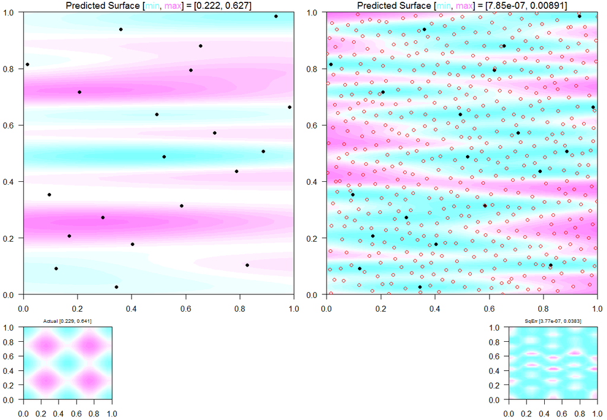

```r
a$run(1, noplot=F)
```

### Second iteration

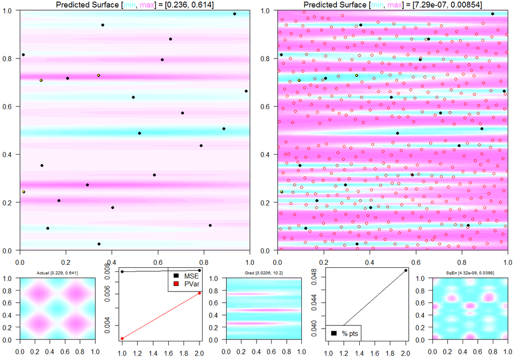

```r
a$run(1)
```

### Third iteration

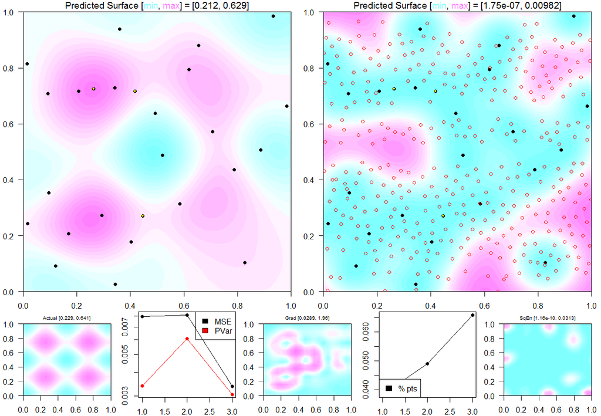

```r
a$run(1)
```

### Fourth iteration

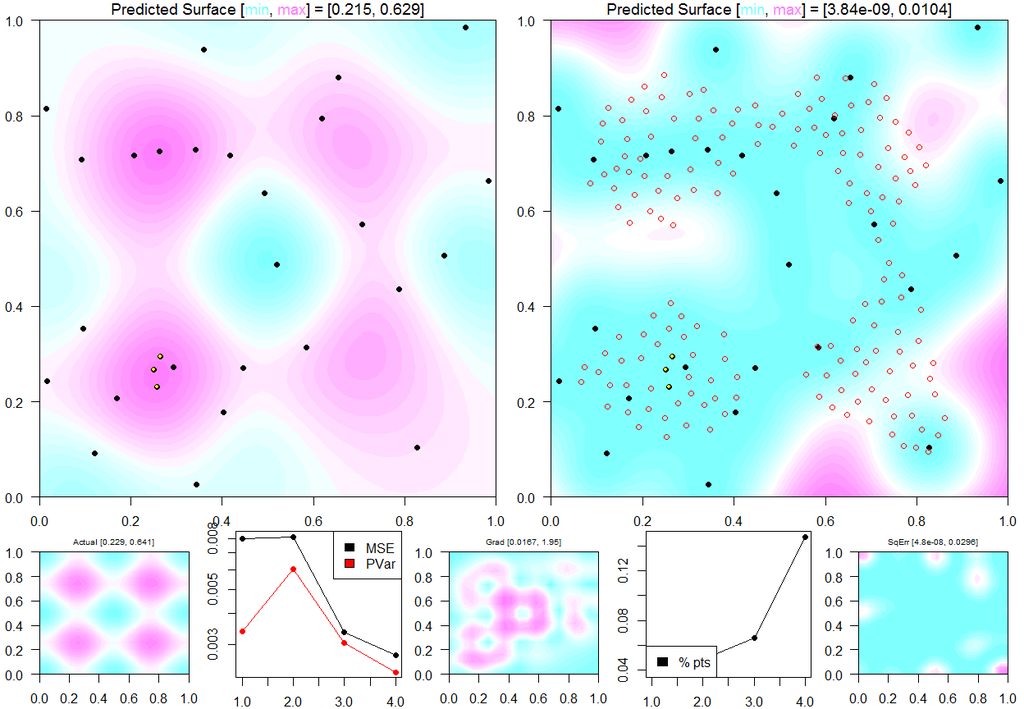

```r
a$run(1)
```

### Fifth iteration

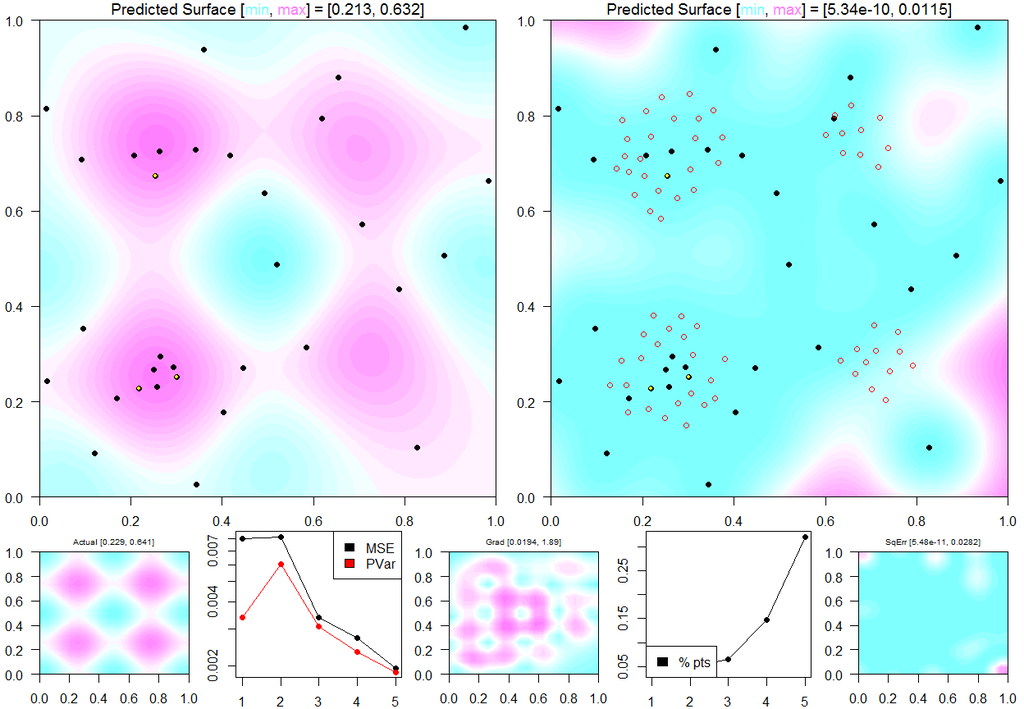

```
## Best design point is
##       0.262 0.725
##  with objective value
##       0.628346
## Best predicted point over domain is
##       0.257 0.744
##  with objective value
##       0.6317774
```

```r
a$run(1)
```